# Ejercicio de repaso final - Módulo 3

Recipes en tidymodels - Aplicación a problemas de inferencia

Diplomatura en Ciencias Sociales Computacionales y Humanidades Digitales (IDAES-UNSAM).

> Material elaborado originalmente por Carolina Pradier y Guido Weksler

```r
library(tidyverse)
library(tidymodels)
library(gt)
library(eph)
library(ggeffects)
library(mfx)

options(dplyr.summarise.inform = FALSE)
theme_set(theme_bw())

conflicted::conflict_prefer("filter", "dplyr")
conflicted::conflict_prefer("select", "dplyr")
```

# 1 Introducción

Este material tiene dos propósitos simultáneos. Por un lado, está destinado a ver la implementación de un ejercicio de regresión logística utilizando varias de las herramientas de **recipes** para preprocesar la información original.Por otro lado, está destinado a discutir un poco sobre el espíritu de utilizar regresiones para la inferencia en el marco de una pregunta de investigación científica. En este caso, partiremos de la pregunta sobre los determinantes de la precariedad laboral (para lo cual aplicaremos un modelo de regresión logística). Luego, extenderemos el ejercicio a evaluar ingresos los determinantes del salario (para lo cual aplicaremos un modelo de regresión lineal).

Utilizaremos como fuente de información la Encuesta Permanente de Hogares.

## 1.1 Breve digresión

¿Cual es mi objetivo como investigador en ciencias sociales?, ¿acaso se trata de utilizar el herramental de econometría para descubrir nuevas relaciones significativas entre variables?. En otros términos, ¿“tirar una regresión como 80.000 variables y encontrar p-valores menores a 5% sería realmente un aporte al **conocimiento** de un fenómeno? Un lindo texto que pone en discusión el método científico [Denari (1991)](https://cicpint.org/es/denari-l-1991a-economia-y-epistemologia-y-los-desaciertos-del-conocimiento-cientifico-realidad-economica-103-81-95/).

Desde nuestro punto de vista, un proceso de conocimiento más potente debe tomar un camino distinto. No podemos pretender explicar un fenómeno simplemente a partir de un modelo que aplique un conjunto de variables que en el mejor de los mundos tenga un `R2` de 60%. Al contrario, creemos que es mucho más potente preguntarse, en primer lugar, por qué existe un fenómeno en el marco de las leyes de la sociedad actual, hasta que nuestro desarrollo nos acerque hacia las variables que podrían encontrarse vinculadas al mismo. ¿Quiere decir esto que la econometría no sirve? Claro que no. Nos permite superar ciertas limitaciones que tiene la estadística descriptiva para, como su nombre lo indica, brindar una **descripción del fenómeno** a partir de su delimitación cualitativa y su cuantificación mediante algún indicador.

# 2 Paquete EPH

Vamos a utilizar el [Paquete eph](https://holatam.github.io/eph/) desarrollado para trabajar en R con la Encuesta Permanente de Hogares. En la página web pueden encontrar una descripción de todas las funcionalidades que tiene. Aquí utilizaremos solo 3 funciones para:

- Descargar una base
- Añadir columnas con distintas categorías del Clasificador de Actividades Económicas (sectores de actividad) y del Clasificador Nacional de Ocupaciones (sector, tecnología, jerarquía y calificación del puesto).

La definición de las variables pueden encontrarla en los [Diseños de Registro](https://www.indec.gob.ar/ftp/cuadros/menusuperior/eph/EPH_registro_2t19.pdf).

# 3 Determinantes de la precariedad laboral

Existen infinidad de discusiones sobre las razones de existencia de los empleos precarios o del sector informal. A los fines de realizar un ejercicio empírico, vamos a partir de las variables que - perdón el autobombo- en este trabajo [**Graña et al (2022)**](https://www.unse.edu.ar/trabajoysociedad/38%20GRANA%20ET%20ALT%20La%20calidad%20del%20empleo%20en%20la%20Argentina.pdf) consideramos centrales para entender la precariedad: el rezago productivo y la diferencia en el valor de la fuerza de trabajo.

De manera muy sintética, se propone allí que la precariedad laboral aparece como una forma en que las empresas de menor tamaño/escala de operación compensan los mayores costos que enfrentan dada su baja producividad (lo cual se operacionaliza con la **variable de cantidad de personas que trabajan en ese establecimiento**) Por otra parte, el segmento de la fuerza laboral sobre la cual recae en mayor medida este “castigo” es aquel segmento que realiza tareas de menores calificaciones, al existir allí mayores masas de reserva de fuerza de trabajo que presionan sobre las condiciones de la fuerza de trabajo en activo (lo cual se operacionaliza con la **variable de calificacion del puesto**). Luego se avanza con estadística descpritiva a partir de estas variables.

Si bien la literatura sobre la precariedad laboral toma en cuenta múltiples expresiones de las condiciones de trabajo para clasificar a una relación laboral como precaria o a un individuo como perteneciente al sector informal, a los fines de simplificar el ejercicio vamos a restringirnos al universo de **asalariados** y a asociar la precariead con la variable **PP07H** vinculada a si en su trabajo le **realizan descuento jubilatorio**. Ajustaremos una regresión logística con esta variable como dependiente.

## 3.1 Preprocesamiento

Cargamos una base de la EPH reciente, filtramos para quedarnos solo con ocupados asalariados.

```r
eph <- eph::get_microdata(year = 2022,trimester = 3)

base_con_clasificadores <-   eph %>%
  filter(ESTADO == 1,CAT_OCUP %in% 3) %>% #Ocupados - Asalariados
  eph::organize_caes() %>%
  eph::organize_cno()
```

```r
# base_con_clasificadores %>%
#   write_rds("base_con_clasificadores.Rds")
# En caso en que por alguna razón no se puedan bajar los datos:
# base_con_clasificadores <- read_rds("base_con_clasificadores.Rds")
```

## 3.2 Grupos de interés

```r
base_asalariados <- base_con_clasificadores %>%
#  eph::organize_labels()%>%
  mutate(
    grupos_calif = factor(case_when(
      CALIFICACION %in% c("Profesionales","Técnicos") ~ "Alta",
      CALIFICACION ==   "Operativos" ~ "Media",
      CALIFICACION ==   "No calificados" ~ "Baja"),
      levels = c("Baja","Media","Alta")),
    precario = factor(case_when(
      PP07H == 1 ~ "No",
      PP07H == 2 ~ "Si"),
      levels = c("No","Si")),
    tamanio_est = factor(case_when(
      PP04C %in% 1:6  | (PP04C %in% 99 & PP04C99 == 1)~ "Chico",
      PP04C %in% 7:8  ~ "Mediano",
      PP04C %in% 9:12 | (PP04C %in% 99 & PP04C99 == 3)~ "Grande"),
      levels = c("Chico","Mediano","Grande")),
    )
```

## 3.3 Estadística descriptiva

¿Qué podemos decir con estadística descriptiva sobre la relación de estas variable con la precariedad?

```r
base_asalariados %>%

  # Asalariados
  filter(!is.na(tamanio_est),!is.na(grupos_calif)) %>%
  group_by(tamanio_est, grupos_calif) %>%
  summarise(casos = sum(PONDERA),
            precarios = sum(PONDERA[precario == "Si"]),
            protegidos = sum(PONDERA[precario == "No"]),
            tasa_precariedad = precarios/casos) %>%
  gt() %>%
  fmt_number()
```

| grupos_calif | casos | precarios | protegidos | tasa_precariedad |
| --- | --- | --- | --- | --- |
| Chico |  |  |  |  |
| Baja | 702,754.00 | 584,148.00 | 118,606.00 | 0.83 |
| Media | 1,444,737.00 | 931,344.00 | 513,393.00 | 0.64 |
| Alta | 341,763.00 | 132,091.00 | 209,672.00 | 0.39 |
| Mediano |  |  |  |  |
| Baja | 199,385.00 | 77,994.00 | 121,391.00 | 0.39 |
| Media | 638,803.00 | 151,551.00 | 487,252.00 | 0.24 |
| Alta | 453,645.00 | 59,061.00 | 394,584.00 | 0.13 |
| Grande |  |  |  |  |
| Baja | 291,831.00 | 63,198.00 | 228,633.00 | 0.22 |
| Media | 1,657,563.00 | 156,101.00 | 1,501,462.00 | 0.09 |
| Alta | 1,275,908.00 | 117,602.00 | 1,158,306.00 | 0.09 |

En principio se observan diferencias que parecen abultadas.

- En los establecimientos de tamaño pequeño (para un mismo nivel de calificaciones) la precariedad es más alta que en los otros dos tamaños.
- A igual categoría de tamaño de establecimiento, en las calificaciones bajas la precariedad siempre es mayor que en las medias y altas.

A pesar de que uno haya desplegado a partir de su “marco teórico” que estas variables son centrales y que los datos dan en orden de lo que allí se plantea, ¿Qué críticas pueden hacerse a esta forma de aproximar el fenómeno? **La ausencia de variables de control**. ¿Cómo puedo garantizar que detrás del dato de alta precariedad en establecimientos pequeños no se “esconde” el hecho de que el grupo de establecimientos pequeños está conformado específicamente por algunas ramas donde suele haber mucho trabajo precario?, En otros términos, quisiera mostrar que lo que mi “teoría” propone rige, aún **controlando por otras variables que puedan estar correlacionadas con la precariedad**.

## 3.4 Modelado (workflow)

A la hora de modelar, agreguemos algunas de las variables típicas que se incluyen como controles en este tipo de ejercicios. Sexo (CH04), Edad (CH06), nivel educativo, rama. Antes de comenzar veamos un poco las variables categóricas que tenemos

```r
table(base_asalariados %>% select(NIVEL_ED) %>% eph::organize_labels()) %>%
   data.frame() %>% gt()
```

| NIVEL_ED | Freq |
| --- | --- |
| Primaria incompleta (incluye educacion especial) | 416 |
| Primaria completa | 1612 |
| Secundaria incompleta | 2598 |
| Secundaria completa | 4983 |
| Superior universitaria incompleta | 2260 |
| Superior universitaria completa | 3921 |
| Sin instruccion | 45 |

```r
table(base_asalariados$caes_eph_label) %>%
  data.frame() %>% gt()
```

| Var1 | Freq |
| --- | --- |
| Actividades primarias | 289 |
| Industria manufacturera | 1426 |
| Construccion | 1257 |
| Comercio | 2142 |
| Hoteles y restaurantes | 582 |
| Transporte, almacenamiento y comunicaciones | 927 |
| Servicios financieros, de alquiler y empresariales | 1259 |
| Administracion publica, defensa y seguridad social | 2461 |
| Ensenanza | 1697 |
| Servicios sociales y de salud | 1278 |
| Servicio domestico | 1527 |
| Otros servicios comunitarios, sociales y personales | 611 |
| Otras ramas | 103 |
| Actividades no bien especificadas | 276 |

```r
receta <- recipe(
  precario ~ grupos_calif +
             tamanio_est +
             CH04 +
             CH06 +
             NIVEL_ED +
             caes_eph_label,
  data = base_asalariados
  ) %>%

  # Imputación de valores faltantes
  step_impute_median(all_numeric_predictors(), id='imp_mediana') %>%
  step_impute_mode(all_nominal_predictors(), id='imp_moda') %>%

  # Variables categóticas
  step_num2factor(CH04, levels = c("Varon", "Mujer"), id='sexo') %>%

  step_mutate(
    NIVEL_ED = ifelse(NIVEL_ED == 7, 1, NIVEL_ED),
    id='nivel_educativo'
  ) %>%

  step_rename(
    EDAD = CH06,
    SEXO = CH04,
    id = 'rename'
  ) %>%

  step_num2factor(
    NIVEL_ED,
    levels = c(
      "Primaria incompleta",
      "Primaria completa",
      "Secundaria incompleta",
      "Secundaria completa",
      "Terciario/univ incompleta",
      "Terciario/univ completa"
    ),
    id='nivel_educativo_factor'
  ) %>%

  step_interact(~ SEXO:EDAD, id='interacciones') %>%

  step_other(caes_eph_label, threshold = 0.05, id='others')

tidy(receta)
```

```
## # A tibble: 8 × 6
##   number operation type          trained skip  id
##    <int> <chr>     <chr>         <lgl>   <lgl> <chr>
## 1      1 step      impute_median FALSE   FALSE imp_mediana
## 2      2 step      impute_mode   FALSE   FALSE imp_moda
## 3      3 step      num2factor    FALSE   FALSE sexo
## 4      4 step      mutate        FALSE   FALSE nivel_educativo
## 5      5 step      rename        FALSE   FALSE rename
## 6      6 step      num2factor    FALSE   FALSE nivel_educativo_factor
## 7      7 step      interact      FALSE   FALSE interacciones
## 8      8 step      other         FALSE   FALSE others
```

```r
modelo <- logistic_reg() %>%
  set_engine('glm')

wf <- workflow() %>%
  add_recipe(receta) %>%
  add_model(modelo)

set.seed(42)
fited_model <- wf %>%
  fit(., data = base_asalariados)

tidy(fited_model) %>%
  gt() %>% fmt_number()
```

| term | estimate | std.error | statistic | p.value |
| --- | --- | --- | --- | --- |
| (Intercept) | 3.23 | 0.17 | 18.66 | 0.00 |
| grupos_califMedia | −0.78 | 0.06 | −13.92 | 0.00 |
| grupos_califAlta | −0.87 | 0.08 | −10.81 | 0.00 |
| tamanio_estMediano | −1.45 | 0.06 | −23.11 | 0.00 |
| tamanio_estGrande | −1.75 | 0.05 | −33.98 | 0.00 |
| SEXOMujer | 0.65 | 0.14 | 4.56 | 0.00 |
| EDAD | −0.04 | 0.00 | −16.17 | 0.00 |
| NIVEL_EDPrimaria completa | −0.45 | 0.13 | −3.50 | 0.00 |
| NIVEL_EDSecundaria incompleta | −0.47 | 0.12 | −3.80 | 0.00 |
| NIVEL_EDSecundaria completa | −1.12 | 0.12 | −9.19 | 0.00 |
| NIVEL_EDTerciario/univ incompleta | −1.05 | 0.13 | −8.03 | 0.00 |
| NIVEL_EDTerciario/univ completa | −1.54 | 0.13 | −11.51 | 0.00 |
| caes_eph_labelConstruccion | 1.13 | 0.10 | 11.62 | 0.00 |
| caes_eph_labelComercio | −0.03 | 0.08 | −0.34 | 0.73 |
| caes_eph_labelTransporte, almacenamiento y comunicaciones | 0.49 | 0.10 | 4.82 | 0.00 |
| caes_eph_labelServicios financieros, de alquiler y empresariales | 0.14 | 0.10 | 1.45 | 0.15 |
| caes_eph_labelAdministracion publica, defensa y seguridad social | −0.61 | 0.10 | −6.31 | 0.00 |
| caes_eph_labelEnsenanza | −0.84 | 0.12 | −6.78 | 0.00 |
| caes_eph_labelServicios sociales y de salud | 0.31 | 0.10 | 3.03 | 0.00 |
| caes_eph_labelServicio domestico | 2.18 | 0.11 | 19.29 | 0.00 |
| caes_eph_labelother | 0.43 | 0.09 | 5.00 | 0.00 |
| SEXOMujer_x_EDAD | −0.01 | 0.00 | −3.16 | 0.00 |

Dado que la EPH contiene una variable para indicar el peso de cada observación (PONDERA), se utilizará para ajustar un modelo equivalente al anterior pero incluyendo pesos según esta variable.

```r
base_asalariados_ponderada <- base_asalariados %>%
  # Con ponderadores completos no converge por lo que los achico para el ejemplo.
  mutate(PONDERA = round(PONDERA/min(PONDERA), 0)) %>%
  mutate(PONDERA = frequency_weights(PONDERA))

base_asalariados_ponderada %>%
  mutate(PONDERA = as.numeric(PONDERA)) %>%
  pull(PONDERA) %>%
  summary()
```

```
##    Min. 1st Qu.  Median    Mean 3rd Qu.    Max.
##    1.00    7.00   12.00   24.63   26.00  366.00
```

```r
receta_ponderada <- recipe(
  precario ~ grupos_calif +
             tamanio_est +
             CH04 +
             CH06 +
             NIVEL_ED +
             caes_eph_label +
             PONDERA,
  data = base_asalariados_ponderada
  ) %>%

  # Variables categóticas
  step_num2factor(CH04, levels = c("Varon", "Mujer"), id='sexo') %>%

  step_mutate(
    NIVEL_ED = ifelse(NIVEL_ED == 7, 1, NIVEL_ED),
    id='nivel_educativo'
  ) %>%

  step_rename(
    EDAD = CH06,
    SEXO = CH04,
    id = 'rename'
  ) %>%

  step_num2factor(
    NIVEL_ED,
    levels = c(
      "Primaria incompleta",
      "Primaria completa",
      "Secundaria incompleta",
      "Secundaria completa",
      "Terciario/univ incompleta",
      "Terciario/univ completa"
    ),
    id='nivel_educativo_factor'
  ) %>%

  step_interact(~ SEXO:EDAD, id='interacciones') %>%

  step_other(caes_eph_label, threshold = 0.05, id='others')


wf_pond <- workflow() %>%
  add_case_weights(PONDERA) %>%
  add_recipe(receta_ponderada) %>%
  add_model(modelo)

fited_model_pond <- wf_pond %>%
  fit(., data = base_asalariados_ponderada)

tidy(fited_model_pond) %>%
  gt() %>% fmt_number()
```

| term | estimate | std.error | statistic | p.value |
| --- | --- | --- | --- | --- |
| (Intercept) | 2.98 | 0.04 | 69.74 | 0.00 |
| grupos_califMedia | −0.69 | 0.01 | −50.90 | 0.00 |
| grupos_califAlta | −0.80 | 0.02 | −42.51 | 0.00 |
| tamanio_estMediano | −1.63 | 0.01 | −119.91 | 0.00 |
| tamanio_estGrande | −2.46 | 0.01 | −193.10 | 0.00 |
| SEXOMujer | 0.60 | 0.03 | 17.44 | 0.00 |
| EDAD | −0.03 | 0.00 | −59.42 | 0.00 |
| NIVEL_EDPrimaria completa | −0.37 | 0.03 | −10.91 | 0.00 |
| NIVEL_EDSecundaria incompleta | −0.41 | 0.03 | −12.45 | 0.00 |
| NIVEL_EDSecundaria completa | −0.92 | 0.03 | −28.71 | 0.00 |
| NIVEL_EDTerciario/univ incompleta | −1.04 | 0.03 | −30.97 | 0.00 |
| NIVEL_EDTerciario/univ completa | −1.23 | 0.03 | −35.91 | 0.00 |
| caes_eph_labelConstruccion | 1.10 | 0.02 | 46.99 | 0.00 |
| caes_eph_labelComercio | −0.14 | 0.02 | −7.47 | 0.00 |
| caes_eph_labelTransporte, almacenamiento y comunicaciones | 0.64 | 0.02 | 28.24 | 0.00 |
| caes_eph_labelServicios financieros, de alquiler y empresariales | 0.11 | 0.02 | 5.47 | 0.00 |
| caes_eph_labelAdministracion publica, defensa y seguridad social | −0.63 | 0.02 | −25.45 | 0.00 |
| caes_eph_labelEnsenanza | −0.74 | 0.03 | −25.92 | 0.00 |
| caes_eph_labelServicios sociales y de salud | 0.63 | 0.02 | 27.11 | 0.00 |
| caes_eph_labelServicio domestico | 1.96 | 0.15 | 13.27 | 0.00 |
| caes_eph_labelother | 0.28 | 0.02 | 14.63 | 0.00 |
| SEXOMujer_x_EDAD | −0.01 | 0.00 | −12.66 | 0.00 |

Para comparar coeficientes lado a lado:

```r
modelsummary::modelsummary(
  list("Modelo sin ponderadores" = fited_model,
       "Modelo con ponderadores" = fited_model_pond
       ),
  statistic = NULL,
  estimate = "{estimate} ({p.value})"
)
```

|  | Modelo sin ponderadores | Modelo con ponderadores |
| --- | --- | --- |
| (Intercept) | 3.231 (<0.001) | 2.981 (<0.001) |
| grupos_califMedia | −0.784 (<0.001) | −0.688 (<0.001) |
| grupos_califAlta | −0.875 (<0.001) | −0.797 (<0.001) |
| tamanio_estMediano | −1.452 (<0.001) | −1.631 (<0.001) |
| tamanio_estGrande | −1.745 (<0.001) | −2.462 (<0.001) |
| SEXOMujer | 0.647 (<0.001) | 0.599 (<0.001) |
| EDAD | −0.039 (<0.001) | −0.033 (<0.001) |
| NIVEL_EDPrimaria completa | −0.450 (<0.001) | −0.372 (<0.001) |
| NIVEL_EDSecundaria incompleta | −0.473 (<0.001) | −0.408 (<0.001) |
| NIVEL_EDSecundaria completa | −1.117 (<0.001) | −0.916 (<0.001) |
| NIVEL_EDTerciario/univ incompleta | −1.046 (<0.001) | −1.039 (<0.001) |
| NIVEL_EDTerciario/univ completa | −1.539 (<0.001) | −1.226 (<0.001) |
| caes_eph_labelConstruccion | 1.132 (<0.001) | 1.097 (<0.001) |
| caes_eph_labelComercio | −0.029 (0.731) | −0.138 (<0.001) |
| caes_eph_labelTransporte, almacenamiento y comunicaciones | 0.490 (<0.001) | 0.641 (<0.001) |
| caes_eph_labelServicios financieros, de alquiler y empresariales | 0.140 (0.146) | 0.115 (<0.001) |
| caes_eph_labelAdministracion publica, defensa y seguridad social | −0.608 (<0.001) | −0.632 (<0.001) |
| caes_eph_labelEnsenanza | −0.836 (<0.001) | −0.743 (<0.001) |
| caes_eph_labelServicios sociales y de salud | 0.312 (0.002) | 0.631 (<0.001) |
| caes_eph_labelServicio domestico | 2.182 (<0.001) | 1.956 (<0.001) |
| caes_eph_labelother | 0.427 (<0.001) | 0.278 (<0.001) |
| SEXOMujer_x_EDAD | −0.011 (0.002) | −0.011 (<0.001) |
| Num.Obs. | 15835 | 12361 |
| AIC | 14356.5 | 247068.2 |
| BIC | 14525.2 | 247231.5 |
| Log.Lik. | −7156.248 | −123512.104 |

El resultado anterior, me da la posibilidad de afirmar estádisticamente una cosa distinta al promedio que tomamos antes: “Aún controlando por otras variables que tipicamente señala la literatura, existe una relación en la cual a mayor tamaño de establecimiento y mayor calificación del puesto de trabajo es menos probable la presencia de precariedad laboral”

Si quisiera mostrar solo las variables de interes en un cuadro puedo filtrar algunos términos del objeto tidy.

```r
tidy(fited_model) %>%
  filter(str_detect(term,"(grupos|tamanio_est|Interc)")) %>%
  gt() %>% fmt_number()
```

| term | estimate | std.error | statistic | p.value |
| --- | --- | --- | --- | --- |
| (Intercept) | 3.23 | 0.17 | 18.66 | 0.00 |
| grupos_califMedia | −0.78 | 0.06 | −13.92 | 0.00 |
| grupos_califAlta | −0.87 | 0.08 | −10.81 | 0.00 |
| tamanio_estMediano | −1.45 | 0.06 | −23.11 | 0.00 |
| tamanio_estGrande | −1.75 | 0.05 | −33.98 | 0.00 |

La función `glance()` me da indicadores de la capacidad de ajuste del modelo (log-likelihood y sus derivados). Si estuviera comparando con otro modelo (loglikelihood más cercanos a 0 son mejores, AIC y BIC más bajos son mejores)

```r
glance(fited_model) %>% gt()
```

| null.deviance | df.null | logLik | AIC | BIC | deviance | df.residual | nobs |
| --- | --- | --- | --- | --- | --- | --- | --- |
| 20826.17 | 15834 | -7156.248 | 14356.5 | 14525.24 | 14312.5 | 15813 | 15835 |

Si quiero ver como se construyeron las variables **dummy** a partir de mis varibles cualitativas, puedo “preparar y cocinar” la receta con las funciones `prep()` y `bake()` respectivamente. Ello me va a dar como resultado el dataframe con las variables transformadas en mis **steps**.  
Luego puedo aplicar la función `contrasts()` sobre alguna variable. Me va a mostrar las columnas suplmentarias creadas. **En caso de no saberlo, puedo chequear que categoría está actuando como base**

```r
receta_cocinada <- receta %>%  #
  prep() %>%
  bake(new_data = NULL)
```

```r
#Categoría base es Industria Manufacturera
contrasts(receta_cocinada$caes_eph_label) %>% data.frame() %>%
  rownames_to_column() %>% gt()
```

|  | Construccion | Comercio | Transporte..almacenamiento.y.comunicaciones | Servicios.financieros..de.alquiler.y.empresariales | Administracion.publica..defensa.y.seguridad.social | Ensenanza | Servicios.sociales.y.de.salud | Servicio.domestico | other |
| --- | --- | --- | --- | --- | --- | --- | --- | --- | --- |
| Industria manufacturera | 0 | 0 | 0 | 0 | 0 | 0 | 0 | 0 | 0 |
| Construccion | 1 | 0 | 0 | 0 | 0 | 0 | 0 | 0 | 0 |
| Comercio | 0 | 1 | 0 | 0 | 0 | 0 | 0 | 0 | 0 |
| Transporte, almacenamiento y comunicaciones | 0 | 0 | 1 | 0 | 0 | 0 | 0 | 0 | 0 |
| Servicios financieros, de alquiler y empresariales | 0 | 0 | 0 | 1 | 0 | 0 | 0 | 0 | 0 |
| Administracion publica, defensa y seguridad social | 0 | 0 | 0 | 0 | 1 | 0 | 0 | 0 | 0 |
| Ensenanza | 0 | 0 | 0 | 0 | 0 | 1 | 0 | 0 | 0 |
| Servicios sociales y de salud | 0 | 0 | 0 | 0 | 0 | 0 | 1 | 0 | 0 |
| Servicio domestico | 0 | 0 | 0 | 0 | 0 | 0 | 0 | 1 | 0 |
| other | 0 | 0 | 0 | 0 | 0 | 0 | 0 | 0 | 1 |

```r
#Categoría base es primaria incompleta
contrasts(receta_cocinada$NIVEL_ED) %>% data.frame() %>%
    rownames_to_column() %>% gt()
```

|  | Primaria.completa | Secundaria.incompleta | Secundaria.completa | Terciario.univ.incompleta | Terciario.univ.completa |
| --- | --- | --- | --- | --- | --- |
| Primaria incompleta | 0 | 0 | 0 | 0 | 0 |
| Primaria completa | 1 | 0 | 0 | 0 | 0 |
| Secundaria incompleta | 0 | 1 | 0 | 0 | 0 |
| Secundaria completa | 0 | 0 | 1 | 0 | 0 |
| Terciario/univ incompleta | 0 | 0 | 0 | 1 | 0 |
| Terciario/univ completa | 0 | 0 | 0 | 0 | 1 |

## 3.5 Efectos marginales

Ahora bien, en el contexto de la inferencia, vimos que en las regresiones logísticas es fácil interpretar el signo de los coeficientes y su significatividad, pero no así el grado en que inciden en la variable a predecir. Una técnica muy usual para sacar conclusiones respecto a las magnitudes es el calculo de lo **efectos marginales**. Esto es, evaluar como incide un movimiento marginal de un predictor `X` en la probabilidad de obtener la clase a predecir `P(Y=1)`. Dado que el movimiento marginal de X en distintos puntos de su distribución genera efectos distintos sobre Y, hay dos opciones principales

- Evaluar el movimiento marginal de X alrededor de su media
- Tomar un promedio de los movimientos marginales observados alrededor de todo el rango de X

**Importante: En ambas opciones siempre se mantiene constante el resto de las variables predictoras**

El paquete [mfx](https://strengejacke.github.io/ggeffects/) permite calcular los efectos marginales para modelos logísticos. Lo que no podemos, por ahora, por diseño de este paquete es integrarlo a la receta generada anteriormente. Sin embargo, podemos utilizar nuestro datafra **receta_cocinada** que ya tiene las transformaciones que le realizamos a la base original.

### 3.5.1 En la media

```r
efectos_marg_en_media <- logitmfx(
    formula = precario ~ grupos_calif +
                         tamanio_est +
                         SEXO +
                         EDAD +
                         NIVEL_ED +
                         caes_eph_label,
    data = receta_cocinada,
    atmean = TRUE
  )

tidy(efectos_marg_en_media) %>%
  gt() %>% fmt_number()
```

| term | atmean | estimate | std.error | statistic | p.value |
| --- | --- | --- | --- | --- | --- |
| grupos_califMedia | TRUE | −0.16 | 0.01 | −13.88 | 0.00 |
| grupos_califAlta | TRUE | −0.17 | 0.01 | −12.01 | 0.00 |
| tamanio_estMediano | TRUE | −0.25 | 0.01 | −29.48 | 0.00 |
| tamanio_estGrande | TRUE | −0.37 | 0.01 | −36.05 | 0.00 |
| SEXOMujer | TRUE | 0.05 | 0.01 | 4.56 | 0.00 |
| EDAD | TRUE | −0.01 | 0.00 | −23.18 | 0.00 |
| NIVEL_EDPrimaria completa | TRUE | −0.09 | 0.02 | −3.86 | 0.00 |
| NIVEL_EDSecundaria incompleta | TRUE | −0.10 | 0.02 | −4.20 | 0.00 |
| NIVEL_EDSecundaria completa | TRUE | −0.22 | 0.02 | −10.36 | 0.00 |
| NIVEL_EDTerciario/univ incompleta | TRUE | −0.19 | 0.02 | −9.94 | 0.00 |
| NIVEL_EDTerciario/univ completa | TRUE | −0.27 | 0.02 | −14.58 | 0.00 |
| caes_eph_labelConstruccion | TRUE | 0.27 | 0.02 | 11.30 | 0.00 |
| caes_eph_labelComercio | TRUE | −0.01 | 0.02 | −0.36 | 0.72 |
| caes_eph_labelTransporte, almacenamiento y comunicaciones | TRUE | 0.11 | 0.02 | 4.66 | 0.00 |
| caes_eph_labelServicios financieros, de alquiler y empresariales | TRUE | 0.03 | 0.02 | 1.43 | 0.15 |
| caes_eph_labelAdministracion publica, defensa y seguridad social | TRUE | −0.12 | 0.02 | −7.10 | 0.00 |
| caes_eph_labelEnsenanza | TRUE | −0.16 | 0.02 | −8.41 | 0.00 |
| caes_eph_labelServicios sociales y de salud | TRUE | 0.07 | 0.02 | 2.80 | 0.01 |
| caes_eph_labelServicio domestico | TRUE | 0.49 | 0.02 | 23.45 | 0.00 |
| caes_eph_labelother | TRUE | 0.10 | 0.02 | 4.84 | 0.00 |

**¿Cómo se lee esto?**  
De manera genérica:

*“Seteando todas las variables continuas en su media y las variables categoricas en su categoría base*:

- Si la variable en cuestión es contínua: un aumento marginal en X genera un cambio de `estimate` en la probabilidad de ser precario”
- Si la variable en cuestión es categórica: Un caso perteneciente a determinada categoría genera un cambio de `estimate` en la probabilidad estimada de ser precario respecto a la categoría que funciona como base”

### 3.5.2 En promedio

Si seteamos el parámetro `atmean = FALSE`, lo que vamos a estar haciendo es calcular un promedio de los efectos marginales a lo largo de distintos momentos de la distribución de las variables (de allí que el procesamiento tarda un poco más).

```r
efectos_marg_promedio <-
  logitmfx(
    formula = precario ~ grupos_calif +
      tamanio_est +
      SEXO +
      EDAD +
      NIVEL_ED +
      caes_eph_label,
    data = receta_cocinada,
    atmean = FALSE
  )

tidy(efectos_marg_promedio) %>%
  gt() %>% fmt_number()
```

| term | atmean | estimate | std.error | statistic | p.value |
| --- | --- | --- | --- | --- | --- |
| grupos_califMedia | FALSE | −0.12 | 0.01 | −13.60 | 0.00 |
| grupos_califAlta | FALSE | −0.13 | 0.01 | −10.89 | 0.00 |
| tamanio_estMediano | FALSE | −0.20 | 0.01 | −25.77 | 0.00 |
| tamanio_estGrande | FALSE | −0.27 | 0.01 | −35.95 | 0.00 |
| SEXOMujer | FALSE | 0.03 | 0.01 | 4.54 | 0.00 |
| EDAD | FALSE | −0.01 | 0.00 | −20.84 | 0.00 |
| NIVEL_EDPrimaria completa | FALSE | −0.06 | 0.02 | −3.68 | 0.00 |
| NIVEL_EDSecundaria incompleta | FALSE | −0.07 | 0.02 | −4.08 | 0.00 |
| NIVEL_EDSecundaria completa | FALSE | −0.16 | 0.02 | −9.89 | 0.00 |
| NIVEL_EDTerciario/univ incompleta | FALSE | −0.14 | 0.02 | −8.71 | 0.00 |
| NIVEL_EDTerciario/univ completa | FALSE | −0.22 | 0.02 | −12.26 | 0.00 |
| caes_eph_labelConstruccion | FALSE | 0.18 | 0.02 | 11.11 | 0.00 |
| caes_eph_labelComercio | FALSE | 0.00 | 0.01 | −0.36 | 0.72 |
| caes_eph_labelTransporte, almacenamiento y comunicaciones | FALSE | 0.07 | 0.02 | 4.83 | 0.00 |
| caes_eph_labelServicios financieros, de alquiler y empresariales | FALSE | 0.02 | 0.01 | 1.45 | 0.15 |
| caes_eph_labelAdministracion publica, defensa y seguridad social | FALSE | −0.09 | 0.01 | −6.46 | 0.00 |
| caes_eph_labelEnsenanza | FALSE | −0.12 | 0.02 | −7.29 | 0.00 |
| caes_eph_labelServicios sociales y de salud | FALSE | 0.04 | 0.02 | 2.89 | 0.00 |
| caes_eph_labelServicio domestico | FALSE | 0.36 | 0.02 | 19.55 | 0.00 |
| caes_eph_labelother | FALSE | 0.06 | 0.01 | 4.96 | 0.00 |

# 4 Determinantes del salario (regresión lineal)

Vamos a recurrir a la eph para estudiar los determinantes del salario usando una regresión lineal.

```r
lm_spec <- linear_reg() %>%
  # set_mode("regression") %>%
  set_engine("lm")
```

Levantamos la base y recodificamos algunas variables:

```r
eph <- eph::get_microdata(year = 2022,trimester = 3)
```

```r
base_con_clasificadores <-   eph %>%
  filter(CH06 !=-1) %>% #Con info de edad
  filter(CH06 >17) %>% #Mayores de edad
  filter(ESTADO == 1) %>% #Ocupados
  filter(CAT_OCUP %in%c(3)) %>% # Asalariados
  eph::organize_caes() %>%
  eph::organize_cno()

#Casos sin info
base_con_clasificadores$P21[base_con_clasificadores$P21 == -9] <- 0
base_con_clasificadores$TOT_P12[base_con_clasificadores$TOT_P12 == -9] <- 0
base_con_clasificadores$PP3E_TOT[base_con_clasificadores$PP3E_TOT == 999] <- 0
base_con_clasificadores$PP3F_TOT[base_con_clasificadores$PP3F_TOT == 999] <- 0

asalariados <- base_con_clasificadores %>%
  filter(P21 > 0, PP3E_TOT > 0) %>% # Asalariados con ingreso y con horas
  mutate(
    grupos.calif = factor(
      case_when(
        CALIFICACION %in% c("Profesionales", "Técnicos") ~ "Alta",
        CALIFICACION ==   "Operativos" ~ "Media",
        CALIFICACION ==   "No calificados" ~ "Baja"
      ),
      levels = c("Baja", "Media", "Alta")
    ),
    precario = factor(
      case_when(
        PP07H == 1 ~ "No",
        PP07H == 2 ~ "Si",
        PP07H == 0 | is.na(PP07H) ~ "No asalariado"
      ),
      levels = c("No", "Si", "No asalariado")
    ),
    tamanio.establecim = factor(
      case_when(
        PP04C %in% 1:6  | (PP04C %in% 99 & PP04C99 == 1) ~ "Pequeño",
        PP04C %in% 7:8  ~ "Mediano",
        PP04C %in% 9:12 | (PP04C %in% 99 & PP04C99 == 3) ~ "Grande"
      ),
      levels = c("Pequeño", "Mediano", "Grande")
    ),
    REGION = factor(
      REGION,
      labels = c("GBA", "NOA", "NEA", "Cuyo", "Pampeana", "Patagonia")
    )
  )
```

Vamos a aplicar una transformación logarítmica al salario porque la distribución está muy sesgada hacia un lado, y la queremos hacer más simétrica para que el modelo funcione.

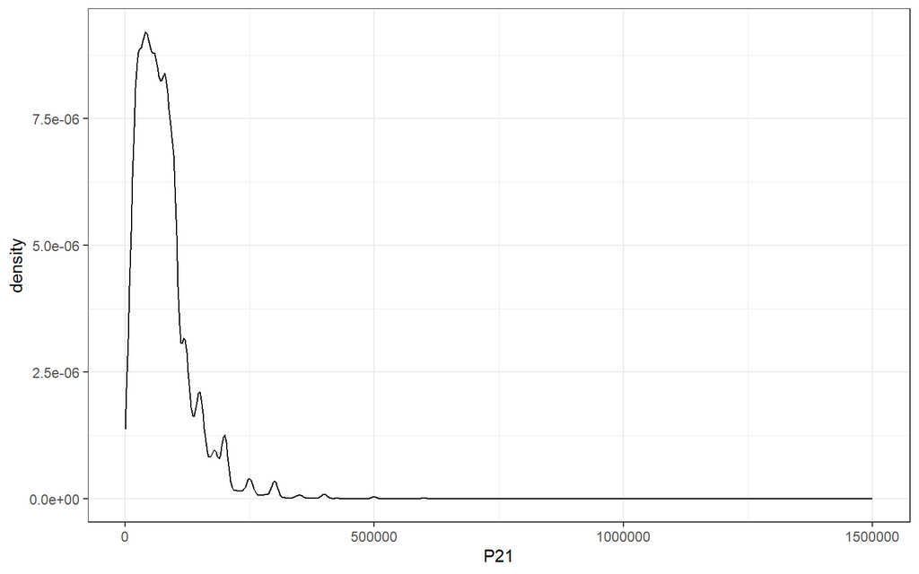

```r
asalariados %>%
  ggplot(.,aes(x=P21))+
  geom_density()
```

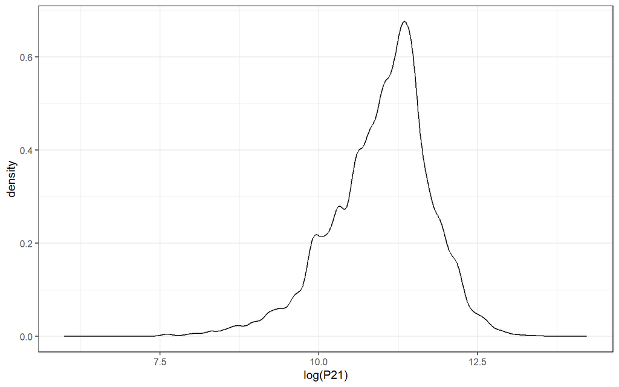

```r
asalariados %>%
  ggplot(.,aes(x=log(P21)))+
  geom_density()
```

Creamos nuestra receta:

```r
receta_mincer <-
  recipe(
    x = asalariados,
    P21 ~  precario +
           grupos.calif +
           tamanio.establecim +
           CH04 +
           CH06 +
           NIVEL_ED +
           caes_eph_label +
           PP3E_TOT +
           REGION
  ) %>%
  step_log(P21, skip = TRUE) %>% #skip permite poder usar augment

  step_impute_mean(all_numeric_predictors()) %>%
  step_impute_mode(all_nominal_predictors()) %>%

  step_num2factor(CH04, levels = c("Varon", "Mujer")) %>%
  step_rename(EDAD = CH06, horas_ocup_ppal = PP3E_TOT) %>%
  step_poly(EDAD, degree = 2) %>%
  #  step_num2factor(REGION, levels = c("GBA","NOA","NEA","Cuyo","Pampeana","Patagonia")) %>%
  #  step_num2factor(PP03G, levels = c("mas_horas","ok_horas")) %>%
  step_mutate(NIVEL_ED = ifelse(NIVEL_ED == 7, yes = 1, no = NIVEL_ED)) %>%
  step_num2factor(
    NIVEL_ED,
    levels = c(
      "Primaria incompleta",
      "Primaria completa",
      "Secundaria incompleta",
      "Secundaria completa",
      "Terciario/univ incompleta",
      "Terciario/univ completa"
    )
  ) %>%
  step_interact(~ CH04:grupos.calif) %>%
  step_other(caes_eph_label, threshold = 0.05)
```

```r
receta_cocinada <- receta_mincer %>%
  prep() %>%
  bake(new_data = NULL)

receta_cocinada %>%
  select(where(is.numeric)) %>%
  skimr::skim()
```

Data summary

| Name | Piped data |
| --- | --- |
| Number of rows | 12628 |
| Number of columns | 6 |
| _______________________ |  |
| Column type frequency: |  |
| numeric | 6 |
| ________________________ |  |
| Group variables | None |

**Variable type: numeric**

| skim_variable | n_missing | complete_rate | mean | sd | p0 | p25 | p50 | p75 | p100 | hist |
| --- | --- | --- | --- | --- | --- | --- | --- | --- | --- | --- |
| horas_ocup_ppal | 0 | 1 | 36.55 | 14.97 | 1.00 | 25.00 | 40.00 | 45.00 | 144.00 | ▃▇▁▁▁ |
| P21 | 0 | 1 | 10.98 | 0.78 | 5.99 | 10.60 | 11.08 | 11.51 | 14.22 | ▁▁▅▇▁ |
| EDAD_poly_1 | 0 | 1 | 0.00 | 0.01 | -0.02 | -0.01 | 0.00 | 0.01 | 0.03 | ▇▇▆▂▁ |
| EDAD_poly_2 | 0 | 1 | 0.00 | 0.01 | -0.01 | -0.01 | 0.00 | 0.00 | 0.09 | ▇▁▁▁▁ |
| CH04Mujer_x_grupos.califMedia | 0 | 1 | 0.17 | 0.38 | 0.00 | 0.00 | 0.00 | 0.00 | 1.00 | ▇▁▁▁▂ |
| CH04Mujer_x_grupos.califAlta | 0 | 1 | 0.13 | 0.34 | 0.00 | 0.00 | 0.00 | 0.00 | 1.00 | ▇▁▁▁▁ |

```r
receta_cocinada %>%
  select(where(is.factor)) %>%
  skimr::skim()
```

Data summary

| Name | Piped data |
| --- | --- |
| Number of rows | 12628 |
| Number of columns | 7 |
| _______________________ |  |
| Column type frequency: |  |
| factor | 7 |
| ________________________ |  |
| Group variables | None |

**Variable type: factor**

| skim_variable | n_missing | complete_rate | ordered | n_unique | top_counts |
| --- | --- | --- | --- | --- | --- |
| precario | 0 | 1 | FALSE | 2 | No: 7969, Si: 4659, No : 0 |
| grupos.calif | 0 | 1 | FALSE | 3 | Med: 6345, Baj: 3320, Alt: 2963 |
| tamanio.establecim | 0 | 1 | FALSE | 3 | Gra: 6700, Peq: 3545, Med: 2383 |
| CH04 | 0 | 1 | FALSE | 2 | Var: 6713, Muj: 5915 |
| NIVEL_ED | 0 | 1 | FALSE | 6 | Sec: 4009, Ter: 2989, Sec: 2097, Ter: 1839 |
| caes_eph_label | 0 | 1 | FALSE | 10 | Adm: 2055, Com: 1706, oth: 1445, Ser: 1280 |
| REGION | 0 | 1 | FALSE | 6 | Pam: 3434, NOA: 3053, Pat: 1789, GBA: 1632 |

```r
#contrasts(receta_cocinada$caes_eph_label)
#contrasts(receta_cocinada$NIVEL_ED)
```

Creamos el workflow:

```r
wf <- workflow() %>%
  add_model(lm_spec) %>%
  add_recipe(receta_mincer)
```

Ajustamos el modelo:

```r
fitted_linear_model <- wf %>%
  fit(.,data = asalariados)
```

Observamos los coeficientes (y su significatividad)

```r
tidy(fitted_linear_model) %>%
  arrange(p.value) %>%
  gt() %>% fmt_number()
```

| term | estimate | std.error | statistic | p.value |
| --- | --- | --- | --- | --- |
| (Intercept) | 10.30 | 0.04 | 275.35 | 0.00 |
| precarioSi | −0.47 | 0.01 | −41.54 | 0.00 |
| horas_ocup_ppal | 0.02 | 0.00 | 51.12 | 0.00 |
| caes_eph_labelServicio domestico | −0.47 | 0.03 | −17.79 | 0.00 |
| EDAD_poly_1 | 9.22 | 0.52 | 17.62 | 0.00 |
| REGIONNOA | −0.23 | 0.01 | −15.88 | 0.00 |
| grupos.califAlta | 0.31 | 0.02 | 14.86 | 0.00 |
| NIVEL_EDTerciario/univ completa | 0.40 | 0.03 | 14.11 | 0.00 |
| REGIONNEA | −0.24 | 0.02 | −13.71 | 0.00 |
| tamanio.establecimGrande | 0.14 | 0.01 | 11.47 | 0.00 |
| REGIONPatagonia | 0.17 | 0.02 | 10.17 | 0.00 |
| EDAD_poly_2 | −4.33 | 0.49 | −8.87 | 0.00 |
| NIVEL_EDTerciario/univ incompleta | 0.25 | 0.03 | 8.83 | 0.00 |
| grupos.califMedia | 0.12 | 0.02 | 7.64 | 0.00 |
| NIVEL_EDSecundaria completa | 0.17 | 0.03 | 6.52 | 0.00 |
| REGIONCuyo | −0.11 | 0.02 | −6.20 | 0.00 |
| CH04Mujer | −0.13 | 0.02 | −6.07 | 0.00 |
| tamanio.establecimMediano | 0.08 | 0.01 | 5.65 | 0.00 |
| caes_eph_labelEnsenanza | −0.11 | 0.02 | −5.12 | 0.00 |
| NIVEL_EDSecundaria incompleta | 0.09 | 0.03 | 3.34 | 0.00 |
| REGIONPampeana | −0.04 | 0.01 | −3.00 | 0.00 |
| caes_eph_labelServicios sociales y de salud | −0.06 | 0.02 | −2.72 | 0.01 |
| caes_eph_labelTransporte, almacenamiento y comunicaciones | 0.06 | 0.02 | 2.55 | 0.01 |
| NIVEL_EDPrimaria completa | 0.05 | 0.03 | 1.92 | 0.06 |
| caes_eph_labelAdministracion publica, defensa y seguridad social | 0.03 | 0.02 | 1.52 | 0.13 |
| caes_eph_labelother | −0.03 | 0.02 | −1.44 | 0.15 |
| CH04Mujer_x_grupos.califMedia | 0.03 | 0.02 | 1.30 | 0.19 |
| caes_eph_labelConstruccion | 0.02 | 0.02 | 1.15 | 0.25 |
| caes_eph_labelServicios financieros, de alquiler y empresariales | −0.01 | 0.02 | −0.35 | 0.73 |
| CH04Mujer_x_grupos.califAlta | −0.01 | 0.03 | −0.25 | 0.80 |
| caes_eph_labelComercio | 0.00 | 0.02 | −0.10 | 0.92 |

```r
gtsummary::tbl_regression(fitted_linear_model)
```

| **Characteristic** | **Beta** | **95% CI**<sup>1</sup> | **p-value** |
| --- | --- | --- | --- |
| precario |  |  |  |
| No | — | — |  |
| Si | -0.47 | -0.50, -0.45 | <0.001 |
| grupos.calif |  |  |  |
| Baja | — | — |  |
| Media | 0.12 | 0.09, 0.15 | <0.001 |
| Alta | 0.31 | 0.27, 0.35 | <0.001 |
| tamanio.establecim |  |  |  |
| Pequeño | — | — |  |
| Mediano | 0.08 | 0.05, 0.10 | <0.001 |
| Grande | 0.14 | 0.11, 0.16 | <0.001 |
| CH04 |  |  |  |
| Varon | — | — |  |
| Mujer | -0.13 | -0.17, -0.09 | <0.001 |
| NIVEL_ED |  |  |  |
| Primaria incompleta | — | — |  |
| Primaria completa | 0.05 | 0.00, 0.11 | 0.055 |
| Secundaria incompleta | 0.09 | 0.04, 0.14 | <0.001 |
| Secundaria completa | 0.17 | 0.12, 0.22 | <0.001 |
| Terciario/univ incompleta | 0.25 | 0.19, 0.30 | <0.001 |
| Terciario/univ completa | 0.40 | 0.34, 0.45 | <0.001 |
| caes_eph_label |  |  |  |
| Industria manufacturera | — | — |  |
| Construccion | 0.02 | -0.02, 0.07 | 0.3 |
| Comercio | 0.00 | -0.04, 0.03 | >0.9 |
| Transporte, almacenamiento y comunicaciones | 0.06 | 0.01, 0.10 | 0.011 |
| Servicios financieros, de alquiler y empresariales | -0.01 | -0.05, 0.03 | 0.7 |
| Administracion publica, defensa y seguridad social | 0.03 | -0.01, 0.06 | 0.13 |
| Ensenanza | -0.11 | -0.16, -0.07 | <0.001 |
| Servicios sociales y de salud | -0.06 | -0.10, -0.02 | 0.007 |
| Servicio domestico | -0.47 | -0.52, -0.41 | <0.001 |
| other | -0.03 | -0.06, 0.01 | 0.2 |
| horas_ocup_ppal | 0.02 | 0.02, 0.02 | <0.001 |
| REGION |  |  |  |
| GBA | — | — |  |
| NOA | -0.23 | -0.26, -0.21 | <0.001 |
| NEA | -0.24 | -0.28, -0.21 | <0.001 |
| Cuyo | -0.11 | -0.14, -0.07 | <0.001 |
| Pampeana | -0.04 | -0.07, -0.01 | 0.003 |
| Patagonia | 0.17 | 0.14, 0.20 | <0.001 |
| EDAD_poly_1 | 9.2 | 8.2, 10 | <0.001 |
| EDAD_poly_2 | -4.3 | -5.3, -3.4 | <0.001 |
| CH04Mujer_x_grupos.califMedia | 0.03 | -0.02, 0.08 | 0.2 |
| CH04Mujer_x_grupos.califAlta | -0.01 | -0.06, 0.05 | 0.8 |

<sup>1</sup> CI = Confidence Interval

Dado que aplicamos una transformación logarítmica a la variable dependiente, la interpretación de los coeficientes se ve modificada. Ahora un incremento en una unidad de X implica una variación de $100 \times (e^{\beta} - 1)$ **%** en Y

Evaluamos el modelo:

```r
glance(fitted_linear_model)
```

```
## # A tibble: 1 × 12
##   r.squared adj.r.squared sigma statistic p.value    df logLik    AIC    BIC
##       <dbl>         <dbl> <dbl>     <dbl>   <dbl> <dbl>  <dbl>  <dbl>  <dbl>
## 1     0.637         0.636 0.472      736.       0    30 -8432. 16927. 17166.
## # ℹ 3 more variables: deviance <dbl>, df.residual <int>, nobs <int>
```

Otra forma de ver todo junto:

```r
fitted_linear_model %>%
  extract_fit_parsnip() %>%
  pluck("fit") %>%
  summary()
```

[output not shown]

Y finalmente graficamos los residuos:

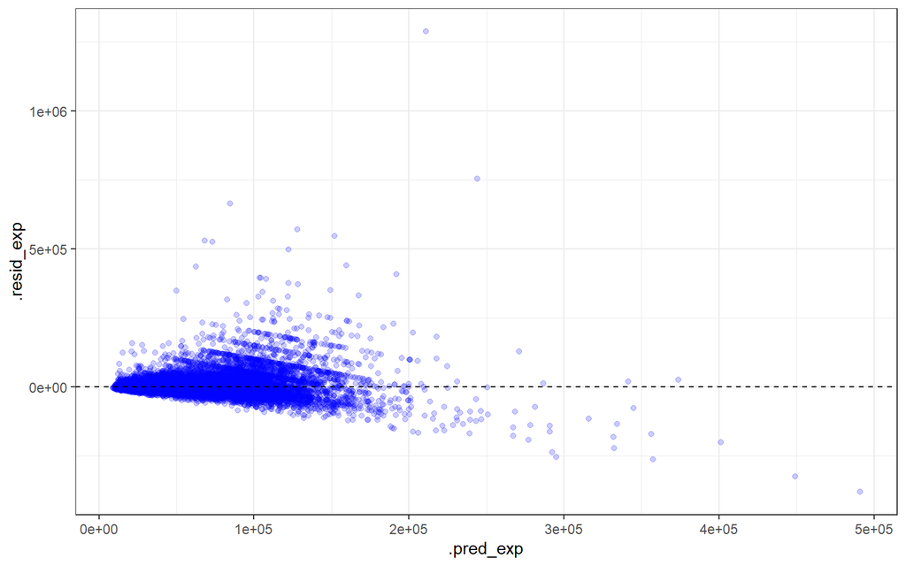

```r
augment(fitted_linear_model, new_data = asalariados) %>%
  mutate(
    .pred_exp = exp(.pred), # Las predicciones están en log
    .resid_exp = P21 - .pred_exp,
    .resid = log(P21) - .pred
  ) %>%
  dplyr::select(.resid, .pred, .resid_exp, .pred_exp) %>%
  #ggplot(aes(x = .pred, y = .resid)) +
  ggplot(aes(x = .pred_exp, y = .resid_exp)) +
    geom_point(alpha=0.2, color='blue') +
    geom_hline(yintercept = 0, linetype = 'dashed')
```